# Visualize ORA results

Stephanie J. Spielman

2026-02-06

This notebook visualizes the odds ratios from over-representation analysis (ORA) performed in `../notebooks/perform-ora.Rmd`, where adjusted p-values were calculated using BH-correction following a permutation test with 10,000 replicates.

Each odds ratio can be interpreted interchangeably as follows, where “outlier” indicates that the gene is in the model residual outliers in either the positive (bulk) or negative (pseudobulk) direction. A bulk outlier is defined as $> 2.5\sigma_{summarized\_residual}$ , and a pseudobulk outlier is defined as $< -2.5\sigma_{summarized\_residual}$ , where the `summarized_residual` values are the median residuals for each gene.

- The odds an outlier is a cell-type marker gene compared to non-outlier
- The odds an cell type marker gene is an outlier compared to other genes

## Setup

```r
renv::load(quiet=TRUE) # needed in case run from command line

library(ggplot2)
theme_set(theme_bw())
```

### Paths

```r
analysis_dir <- here::here("analysis", "pseudobulk-bulk-prediction")
result_dir <- file.path(analysis_dir, "results")
```

Define files to read in:

```r
odds_files <- list.files(
  path = result_dir,
  full.names = TRUE,
  pattern = "_ORA-odds-ratios\\.tsv$"
)
odds_names <- stringr::str_split_i(basename(odds_files), pattern = "_", i = 1)
names(odds_files) <- odds_names
```

### Read and prepare data

```r
odds_df <- odds_files |>
  purrr::map(readr::read_tsv, show_col_types = FALSE)  |>
  purrr::list_rbind(names_to = "project_id")
```

Filter to significant results, and arrange by *descending* adjusted p for only viewing in this chunk

```r
# all are in bulk direction
signif_df <- odds_df |>
  dplyr::filter(p_adj_bh <= 0.05)

dplyr::arrange(signif_df, desc(p_adj_bh))
```

| project_id | geneset_cell_type | modality | odds_ratio | p_value | p_adj_bh |
| --- | --- | --- | --- | --- | --- |
| SCPCP000017 | Pericytes | bulk | 5.305009 | 0.02439756 | 0.04879512 |
| SCPCP000009 | Monocytes | bulk | 3.783546 | 0.02339766 | 0.04679532 |
| SCPCP000017 | Osteoblasts | bulk | 5.305009 | 0.02189781 | 0.04379562 |
| SCPCP000017 | Chondrocytes | bulk | 6.522272 | 0.01399860 | 0.02799720 |
| SCPCP000017 | Gamma delta T cells | bulk | 6.389028 | 0.01259874 | 0.02519748 |
| SCPCP000017 | Osteoclasts | bulk | 6.806139 | 0.01089891 | 0.02179782 |
| SCPCP000017 | Macrophages | bulk | 4.289251 | 0.00759924 | 0.01519848 |
| SCPCP000001 | Meningeal cells | bulk | 19.354839 | 0.00719928 | 0.01439856 |
| SCPCP000001 | Ependymal cells | bulk | 8.394884 | 0.00689931 | 0.01379862 |
| SCPCP000006 | Monocytes | bulk | 8.214823 | 0.00679932 | 0.01359864 |

[output cut: 27 more lines]

The modality for all significant results is `bulk`. This means that all significant gene sets (cell types) are over-represented in bulk compared to pseudobulk. We did not recover evidence that any gene sets are over-represented in pseudobulk compared to bulk.

Next, we’ll plot the odds ratios, colored by `-log10(adjusted pvalue)`.

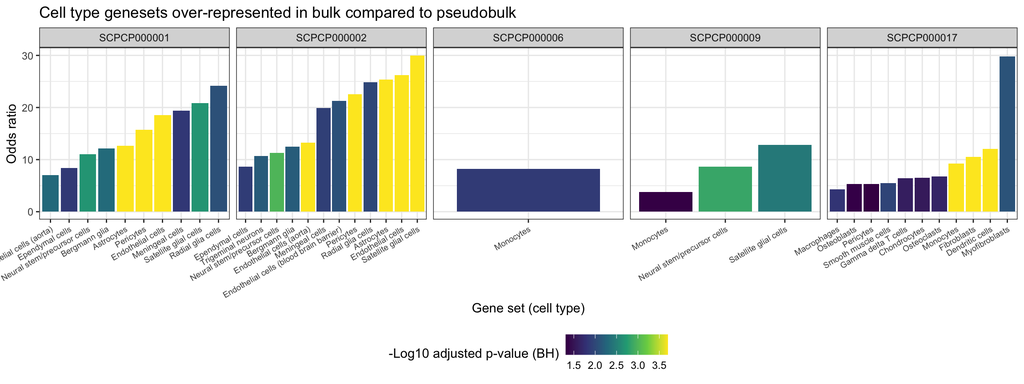

```r
ggplot(signif_df) +
  aes(
    x = tidytext::reorder_within(geneset_cell_type, odds_ratio, within = project_id),
    y = odds_ratio,
    fill = -log10(p_adj_bh)
  ) +
  geom_col() +
  scale_fill_viridis_c() +
  tidytext::scale_x_reordered() + # gets the labels back to only geneset_cell_type
  facet_wrap(vars(project_id), scales = "free_x", nrow = 1) +
  labs(
    x = "Gene set (cell type)",
    y = "Odds ratio",
    fill = "-Log10 adjusted p-value (BH)",
    title = "Cell type genesets over-represented in bulk compared to pseudobulk"
  ) +
  theme(
    legend.position = "bottom",
    axis.text.x = element_text(angle = 30, hjust = 1, size = 7)
  )
```

Each individual odds ratio can be interpreted as, for example considering monocytes in `SCPCP000006`, either:

- The odds a monocyte marker gene is an bulk-direction outlier are ~8x higher than the odds another gene is an outlier.
- The odds a bulk-direction outlier is a monocyte marker gene are ~8x higher than the odds a non-outlier is a monocyte marker gene.

Noting for a publication-type figure, we’d want to include information like:

- How many samples were included in each project
- How many total gene sets were tested for each project
- Potentially, how many marker genes are in each gene set

Some of this information may be better suited for a table.